# examples_0113

Find the solutions to the quadratic equation below.
$$z^{2} - 18 z + 106=0$$

Both solutions will be complex numbers (because the discriminant is negative). To find the solutions, I'd recommend using [this website](https://samuelj.li/complex-function-plotter/#z%5E2-18*z%2B106), which uses [domain coloring](https://en.wikipedia.org/wiki/Domain_coloring) to visualize the solutions. By default the solutions will appear as the center of concentric rings.

Whenever a quadratic equation with REAL coefficients has COMPLEX solutions, the two solutions are [complex conjugates](https://en.wikipedia.org/wiki/Complex_conjugate). In other words, the solutions can be expressed as $x=h-wi$ and $x=h+wi$, where $i=\sqrt{-1}$. Find $h$ and $w$.

$h=$

$w=$

Use [this website](https://samuelj.li/complex-function-plotter/#z%5E2-18*z%2B106). It should automatically have the function typed in.

Zoom out. Notice two "circles". Zoom into a circle to find the real component $h$ and the imaginary component $w$. You will find solutions at $9-5i$ and $9+5i$. So,

$$h=9$$
$$w=5$$

Find the solutions to the quadratic equation below.
$$z^{2} - 8 z + 41=0$$

Both solutions will be complex numbers (because the discriminant is negative). To find the solutions, I'd recommend using [this website](https://samuelj.li/complex-function-plotter/#z%5E2-8*z%2B41), which uses [domain coloring](https://en.wikipedia.org/wiki/Domain_coloring) to visualize the solutions. By default the solutions will appear as the center of concentric rings.

Whenever a quadratic equation with REAL coefficients has COMPLEX solutions, the two solutions are [complex conjugates](https://en.wikipedia.org/wiki/Complex_conjugate). In other words, the solutions can be expressed as $x=h-wi$ and $x=h+wi$, where $i=\sqrt{-1}$. Find $h$ and $w$.

$h=$

$w=$

Use [this website](https://samuelj.li/complex-function-plotter/#z%5E2-8*z%2B41). It should automatically have the function typed in.

Zoom out. Notice two "circles". Zoom into a circle to find the real component $h$ and the imaginary component $w$. You will find solutions at $4-5i$ and $4+5i$. So,

$$h=4$$
$$w=5$$

Find the solutions to the quadratic equation below.
$$z^{2} + 10 z + 61=0$$

Both solutions will be complex numbers (because the discriminant is negative). To find the solutions, I'd recommend using [this website](https://samuelj.li/complex-function-plotter/#z%5E2%2B10*z%2B61), which uses [domain coloring](https://en.wikipedia.org/wiki/Domain_coloring) to visualize the solutions. By default the solutions will appear as the center of concentric rings.

Whenever a quadratic equation with REAL coefficients has COMPLEX solutions, the two solutions are [complex conjugates](https://en.wikipedia.org/wiki/Complex_conjugate). In other words, the solutions can be expressed as $x=h-wi$ and $x=h+wi$, where $i=\sqrt{-1}$. Find $h$ and $w$.

$h=$

$w=$

Use [this website](https://samuelj.li/complex-function-plotter/#z%5E2%2B10*z%2B61). It should automatically have the function typed in.

Zoom out. Notice two "circles". Zoom into a circle to find the real component $h$ and the imaginary component $w$. You will find solutions at $-5-6i$ and $-5+6i$. So,

$$h=-5$$
$$w=6$$

Find the solutions to the quadratic equation below.
$$z^{2} + 6 z + 34=0$$

Both solutions will be complex numbers (because the discriminant is negative). To find the solutions, I'd recommend using [this website](https://samuelj.li/complex-function-plotter/#z%5E2%2B6*z%2B34), which uses [domain coloring](https://en.wikipedia.org/wiki/Domain_coloring) to visualize the solutions. By default the solutions will appear as the center of concentric rings.

Whenever a quadratic equation with REAL coefficients has COMPLEX solutions, the two solutions are [complex conjugates](https://en.wikipedia.org/wiki/Complex_conjugate). In other words, the solutions can be expressed as $x=h-wi$ and $x=h+wi$, where $i=\sqrt{-1}$. Find $h$ and $w$.

$h=$

$w=$

Use [this website](https://samuelj.li/complex-function-plotter/#z%5E2%2B6*z%2B34). It should automatically have the function typed in.

Zoom out. Notice two "circles". Zoom into a circle to find the real component $h$ and the imaginary component $w$. You will find solutions at $-3-5i$ and $-3+5i$. So,

$$h=-3$$
$$w=5$$

Find the solutions to the quadratic equation below.
$$z^{2} - 6 z + 73=0$$

Both solutions will be complex numbers (because the discriminant is negative). To find the solutions, I'd recommend using [this website](https://samuelj.li/complex-function-plotter/#z%5E2-6*z%2B73), which uses [domain coloring](https://en.wikipedia.org/wiki/Domain_coloring) to visualize the solutions. By default the solutions will appear as the center of concentric rings.

Whenever a quadratic equation with REAL coefficients has COMPLEX solutions, the two solutions are [complex conjugates](https://en.wikipedia.org/wiki/Complex_conjugate). In other words, the solutions can be expressed as $x=h-wi$ and $x=h+wi$, where $i=\sqrt{-1}$. Find $h$ and $w$.

$h=$

$w=$

Use [this website](https://samuelj.li/complex-function-plotter/#z%5E2-6*z%2B73). It should automatically have the function typed in.

Zoom out. Notice two "circles". Zoom into a circle to find the real component $h$ and the imaginary component $w$. You will find solutions at $3-8i$ and $3+8i$. So,

$$h=3$$
$$w=8$$

Find the solutions to the quadratic equation below.
$$z^{2} - 18 z + 130=0$$

Both solutions will be complex numbers (because the discriminant is negative). To find the solutions, I'd recommend using [this website](https://samuelj.li/complex-function-plotter/#z%5E2-18*z%2B130), which uses [domain coloring](https://en.wikipedia.org/wiki/Domain_coloring) to visualize the solutions. By default the solutions will appear as the center of concentric rings.

Whenever a quadratic equation with REAL coefficients has COMPLEX solutions, the two solutions are [complex conjugates](https://en.wikipedia.org/wiki/Complex_conjugate). In other words, the solutions can be expressed as $x=h-wi$ and $x=h+wi$, where $i=\sqrt{-1}$. Find $h$ and $w$.

$h=$

$w=$

Use [this website](https://samuelj.li/complex-function-plotter/#z%5E2-18*z%2B130). It should automatically have the function typed in.

Zoom out. Notice two "circles". Zoom into a circle to find the real component $h$ and the imaginary component $w$. You will find solutions at $9-7i$ and $9+7i$. So,

$$h=9$$
$$w=7$$

Find the solutions to the quadratic equation below.
$$z^{2} - 10 z + 34=0$$

Both solutions will be complex numbers (because the discriminant is negative). To find the solutions, I'd recommend using [this website](https://samuelj.li/complex-function-plotter/#z%5E2-10*z%2B34), which uses [domain coloring](https://en.wikipedia.org/wiki/Domain_coloring) to visualize the solutions. By default the solutions will appear as the center of concentric rings.

Whenever a quadratic equation with REAL coefficients has COMPLEX solutions, the two solutions are [complex conjugates](https://en.wikipedia.org/wiki/Complex_conjugate). In other words, the solutions can be expressed as $x=h-wi$ and $x=h+wi$, where $i=\sqrt{-1}$. Find $h$ and $w$.

$h=$

$w=$

Use [this website](https://samuelj.li/complex-function-plotter/#z%5E2-10*z%2B34). It should automatically have the function typed in.

Zoom out. Notice two "circles". Zoom into a circle to find the real component $h$ and the imaginary component $w$. You will find solutions at $5-3i$ and $5+3i$. So,

$$h=5$$
$$w=3$$

Find the solutions to the quadratic equation below.
$$z^{2} + 16 z + 145=0$$

Both solutions will be complex numbers (because the discriminant is negative). To find the solutions, I'd recommend using [this website](https://samuelj.li/complex-function-plotter/#z%5E2%2B16*z%2B145), which uses [domain coloring](https://en.wikipedia.org/wiki/Domain_coloring) to visualize the solutions. By default the solutions will appear as the center of concentric rings.

Whenever a quadratic equation with REAL coefficients has COMPLEX solutions, the two solutions are [complex conjugates](https://en.wikipedia.org/wiki/Complex_conjugate). In other words, the solutions can be expressed as $x=h-wi$ and $x=h+wi$, where $i=\sqrt{-1}$. Find $h$ and $w$.

$h=$

$w=$

Use [this website](https://samuelj.li/complex-function-plotter/#z%5E2%2B16*z%2B145). It should automatically have the function typed in.

Zoom out. Notice two "circles". Zoom into a circle to find the real component $h$ and the imaginary component $w$. You will find solutions at $-8-9i$ and $-8+9i$. So,

$$h=-8$$
$$w=9$$

Find the solutions to the quadratic equation below.
$$z^{2} + 18 z + 145=0$$

Both solutions will be complex numbers (because the discriminant is negative). To find the solutions, I'd recommend using [this website](https://samuelj.li/complex-function-plotter/#z%5E2%2B18*z%2B145), which uses [domain coloring](https://en.wikipedia.org/wiki/Domain_coloring) to visualize the solutions. By default the solutions will appear as the center of concentric rings.

Whenever a quadratic equation with REAL coefficients has COMPLEX solutions, the two solutions are [complex conjugates](https://en.wikipedia.org/wiki/Complex_conjugate). In other words, the solutions can be expressed as $x=h-wi$ and $x=h+wi$, where $i=\sqrt{-1}$. Find $h$ and $w$.

$h=$

$w=$

Use [this website](https://samuelj.li/complex-function-plotter/#z%5E2%2B18*z%2B145). It should automatically have the function typed in.

Zoom out. Notice two "circles". Zoom into a circle to find the real component $h$ and the imaginary component $w$. You will find solutions at $-9-8i$ and $-9+8i$. So,

$$h=-9$$
$$w=8$$

Find the solutions to the quadratic equation below.
$$z^{2} - 20 z + 109=0$$

Both solutions will be complex numbers (because the discriminant is negative). To find the solutions, I'd recommend using [this website](https://samuelj.li/complex-function-plotter/#z%5E2-20*z%2B109), which uses [domain coloring](https://en.wikipedia.org/wiki/Domain_coloring) to visualize the solutions. By default the solutions will appear as the center of concentric rings.

Whenever a quadratic equation with REAL coefficients has COMPLEX solutions, the two solutions are [complex conjugates](https://en.wikipedia.org/wiki/Complex_conjugate). In other words, the solutions can be expressed as $x=h-wi$ and $x=h+wi$, where $i=\sqrt{-1}$. Find $h$ and $w$.

$h=$

$w=$

Use [this website](https://samuelj.li/complex-function-plotter/#z%5E2-20*z%2B109). It should automatically have the function typed in.

Zoom out. Notice two "circles". Zoom into a circle to find the real component $h$ and the imaginary component $w$. You will find solutions at $10-3i$ and $10+3i$. So,

$$h=10$$
$$w=3$$

Let $z_1$ be a complex number with integer components. It is graphed on a [complex plane](https://en.wikipedia.org/wiki/Complex_plane) below, along with a segment connecting it to the origin.

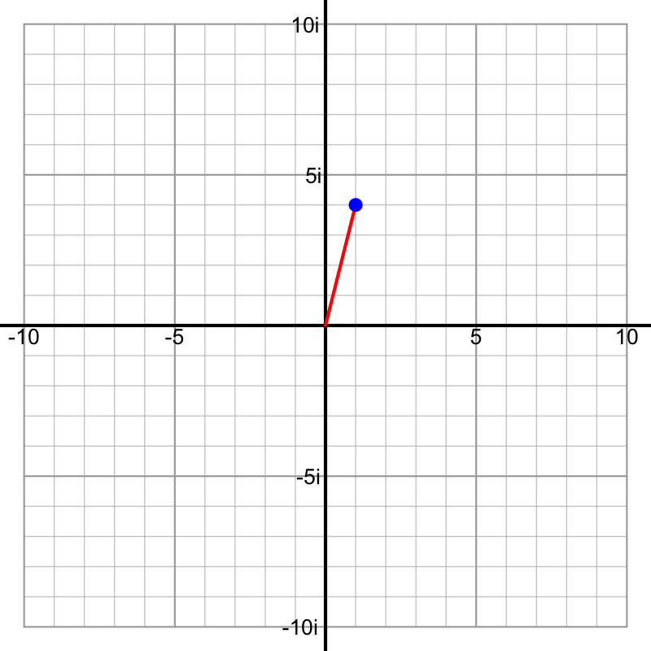

The [modulus](https://en.wikipedia.org/wiki/Absolute_value#Complex_numbers) of a complex number is analogous to finding distance on a 2D Cartesian plane from the origin to a point. If complex number $z=a+bi$ then its modulus, $|z|$, is calculated with a variation on the distance formula:
$$|z|=\sqrt{a^2+b^2}$$
Calculate $|z_1|$. *The tolerance is $\pm 0.01$.*

The horizontal (real) component is 1. The vertical (imaginary) component is 4. So,
$$z_1 = 1+4i$$

Use the formula.
$$|z_1| =
\sqrt{(1)^2+(4)^2}$$
$$|z_1| =
\sqrt{1+16}$$
$$|z_1| = \sqrt{17}
\approx 4.1231056$$

Let $z_1$ be a complex number with integer components. It is graphed on a [complex plane](https://en.wikipedia.org/wiki/Complex_plane) below, along with a segment connecting it to the origin.

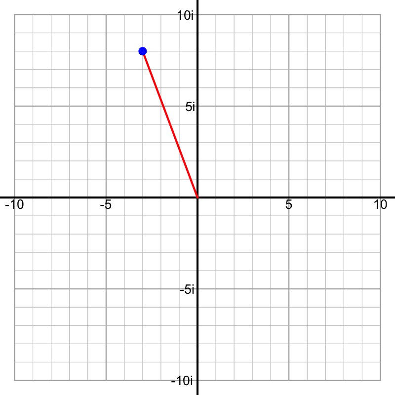

The [modulus](https://en.wikipedia.org/wiki/Absolute_value#Complex_numbers) of a complex number is analogous to finding distance on a 2D Cartesian plane from the origin to a point. If complex number $z=a+bi$ then its modulus, $|z|$, is calculated with a variation on the distance formula:
$$|z|=\sqrt{a^2+b^2}$$
Calculate $|z_1|$. *The tolerance is $\pm 0.01$.*

The horizontal (real) component is -3. The vertical (imaginary) component is 8. So,
$$z_1 =
-3+8i$$

Use the formula.
$$|z_1| =
\sqrt{(-3)^2+(8)^2}$$
$$|z_1| =
\sqrt{9+64}$$
$$|z_1| = \sqrt{73}
\approx 8.5440037$$

Let $z_1$ be a complex number with integer components. It is graphed on a [complex plane](https://en.wikipedia.org/wiki/Complex_plane) below, along with a segment connecting it to the origin.

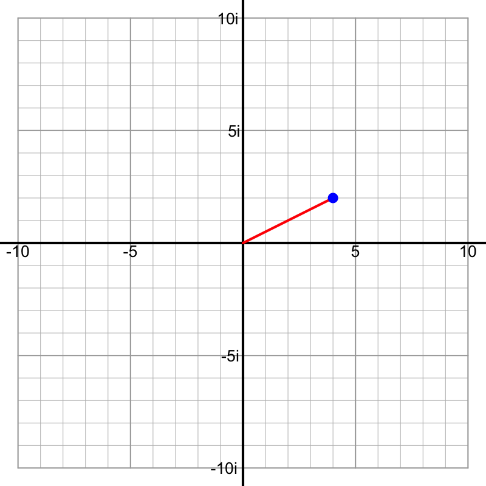

The [modulus](https://en.wikipedia.org/wiki/Absolute_value#Complex_numbers) of a complex number is analogous to finding distance on a 2D Cartesian plane from the origin to a point. If complex number $z=a+bi$ then its modulus, $|z|$, is calculated with a variation on the distance formula:
$$|z|=\sqrt{a^2+b^2}$$
Calculate $|z_1|$. *The tolerance is $\pm 0.01$.*

The horizontal (real) component is 4. The vertical (imaginary) component is 2. So,
$$z_1 = 4+2i$$

Use the formula.
$$|z_1| =
\sqrt{(4)^2+(2)^2}$$
$$|z_1| =
\sqrt{16+4}$$
$$|z_1| = \sqrt{20}
\approx 4.472136$$

Let $z_1$ be a complex number with integer components. It is graphed on a [complex plane](https://en.wikipedia.org/wiki/Complex_plane) below, along with a segment connecting it to the origin.

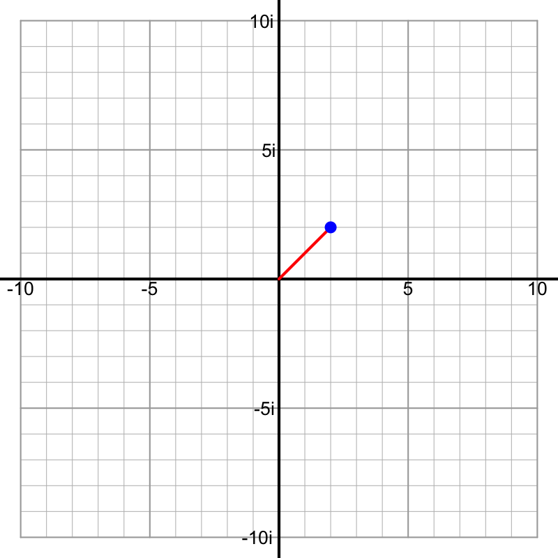

The [modulus](https://en.wikipedia.org/wiki/Absolute_value#Complex_numbers) of a complex number is analogous to finding distance on a 2D Cartesian plane from the origin to a point. If complex number $z=a+bi$ then its modulus, $|z|$, is calculated with a variation on the distance formula:
$$|z|=\sqrt{a^2+b^2}$$
Calculate $|z_1|$. *The tolerance is $\pm 0.01$.*

The horizontal (real) component is 2. The vertical (imaginary) component is 2. So,
$$z_1 = 2+2i$$

Use the formula.
$$|z_1| =
\sqrt{(2)^2+(2)^2}$$
$$|z_1| =
\sqrt{4+4}$$
$$|z_1| = \sqrt{8}
\approx 2.8284271$$

Let $z_1$ be a complex number with integer components. It is graphed on a [complex plane](https://en.wikipedia.org/wiki/Complex_plane) below, along with a segment connecting it to the origin.

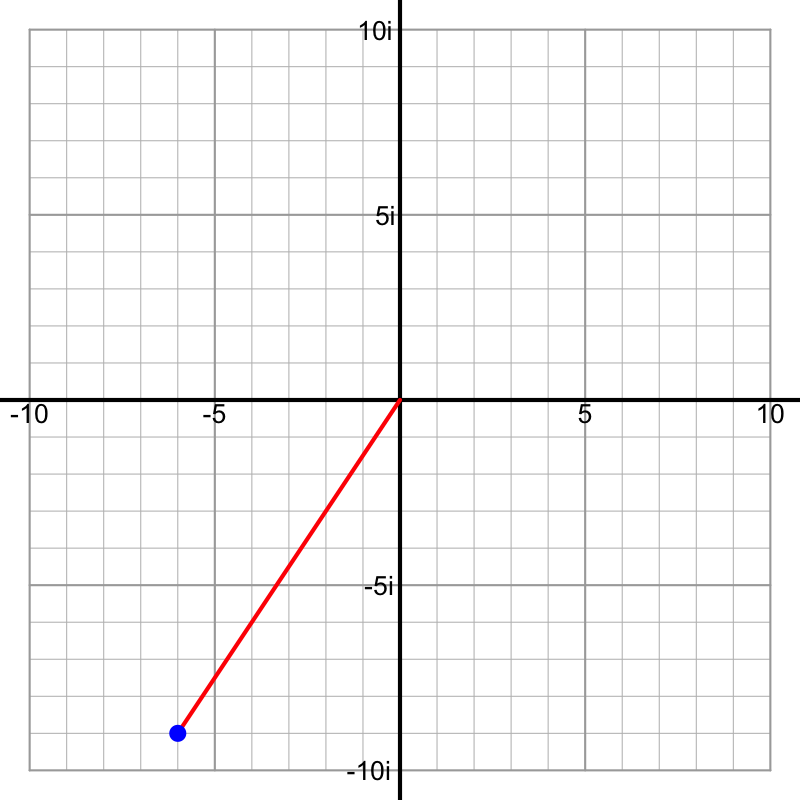

The [modulus](https://en.wikipedia.org/wiki/Absolute_value#Complex_numbers) of a complex number is analogous to finding distance on a 2D Cartesian plane from the origin to a point. If complex number $z=a+bi$ then its modulus, $|z|$, is calculated with a variation on the distance formula:
$$|z|=\sqrt{a^2+b^2}$$
Calculate $|z_1|$. *The tolerance is $\pm 0.01$.*

The horizontal (real) component is -6. The vertical (imaginary) component is -9. So,
$$z_1 =
-6-9i$$

Use the formula.
$$|z_1| =
\sqrt{(-6)^2+(-9)^2}$$
$$|z_1| =
\sqrt{36+81}$$
$$|z_1| = \sqrt{117}
\approx 10.8166538$$

Let $z_1$ be a complex number with integer components. It is graphed on a [complex plane](https://en.wikipedia.org/wiki/Complex_plane) below, along with a segment connecting it to the origin.

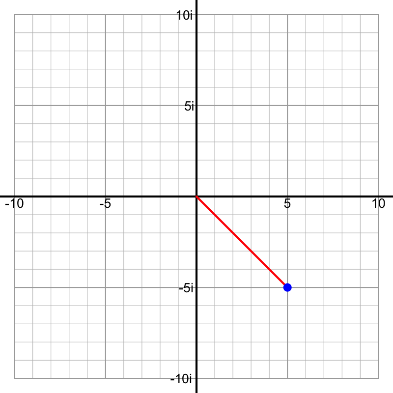

The [modulus](https://en.wikipedia.org/wiki/Absolute_value#Complex_numbers) of a complex number is analogous to finding distance on a 2D Cartesian plane from the origin to a point. If complex number $z=a+bi$ then its modulus, $|z|$, is calculated with a variation on the distance formula:
$$|z|=\sqrt{a^2+b^2}$$
Calculate $|z_1|$. *The tolerance is $\pm 0.01$.*

The horizontal (real) component is 5. The vertical (imaginary) component is -5. So,
$$z_1 =
5-5i$$

Use the formula.
$$|z_1| =
\sqrt{(5)^2+(-5)^2}$$
$$|z_1| =
\sqrt{25+25}$$
$$|z_1| = \sqrt{50}
\approx 7.0710678$$

Let $z_1$ be a complex number with integer components. It is graphed on a [complex plane](https://en.wikipedia.org/wiki/Complex_plane) below, along with a segment connecting it to the origin.

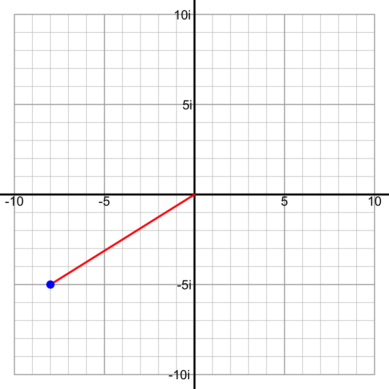

The [modulus](https://en.wikipedia.org/wiki/Absolute_value#Complex_numbers) of a complex number is analogous to finding distance on a 2D Cartesian plane from the origin to a point. If complex number $z=a+bi$ then its modulus, $|z|$, is calculated with a variation on the distance formula:
$$|z|=\sqrt{a^2+b^2}$$
Calculate $|z_1|$. *The tolerance is $\pm 0.01$.*

The horizontal (real) component is -8. The vertical (imaginary) component is -5. So,
$$z_1 =
-8-5i$$

Use the formula.
$$|z_1| =
\sqrt{(-8)^2+(-5)^2}$$
$$|z_1| =
\sqrt{64+25}$$
$$|z_1| = \sqrt{89}
\approx 9.4339811$$

Let $z_1$ be a complex number with integer components. It is graphed on a [complex plane](https://en.wikipedia.org/wiki/Complex_plane) below, along with a segment connecting it to the origin.

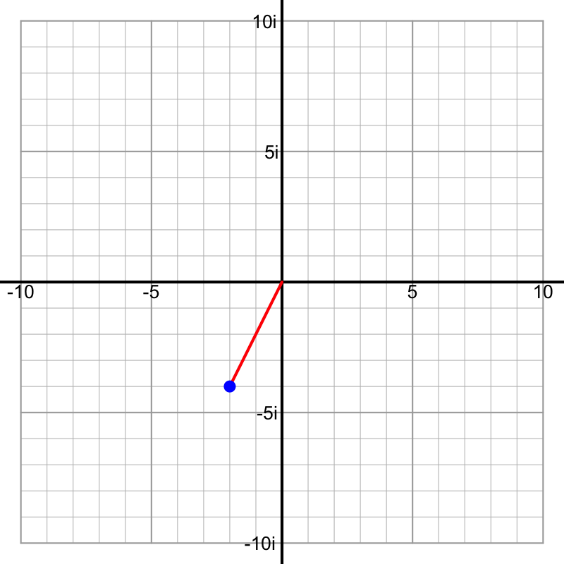

The [modulus](https://en.wikipedia.org/wiki/Absolute_value#Complex_numbers) of a complex number is analogous to finding distance on a 2D Cartesian plane from the origin to a point. If complex number $z=a+bi$ then its modulus, $|z|$, is calculated with a variation on the distance formula:
$$|z|=\sqrt{a^2+b^2}$$
Calculate $|z_1|$. *The tolerance is $\pm 0.01$.*

The horizontal (real) component is -2. The vertical (imaginary) component is -4. So,
$$z_1 =
-2-4i$$

Use the formula.
$$|z_1| =
\sqrt{(-2)^2+(-4)^2}$$
$$|z_1| =
\sqrt{4+16}$$
$$|z_1| = \sqrt{20}
\approx 4.472136$$

Let $z_1$ be a complex number with integer components. It is graphed on a [complex plane](https://en.wikipedia.org/wiki/Complex_plane) below, along with a segment connecting it to the origin.

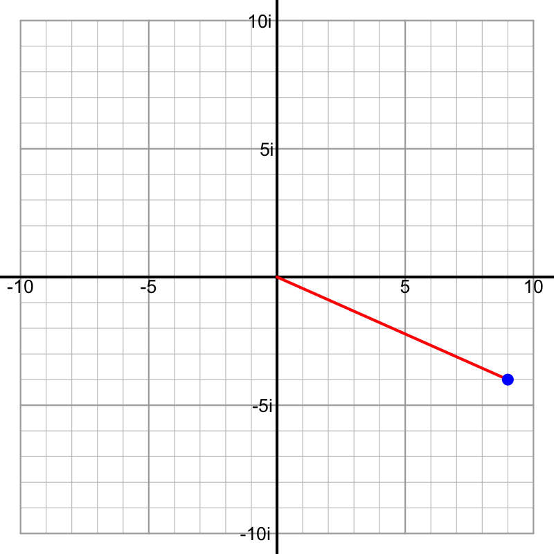

The [modulus](https://en.wikipedia.org/wiki/Absolute_value#Complex_numbers) of a complex number is analogous to finding distance on a 2D Cartesian plane from the origin to a point. If complex number $z=a+bi$ then its modulus, $|z|$, is calculated with a variation on the distance formula:
$$|z|=\sqrt{a^2+b^2}$$
Calculate $|z_1|$. *The tolerance is $\pm 0.01$.*

The horizontal (real) component is 9. The vertical (imaginary) component is -4. So,
$$z_1 =
9-4i$$

Use the formula.
$$|z_1| =
\sqrt{(9)^2+(-4)^2}$$
$$|z_1| =
\sqrt{81+16}$$
$$|z_1| = \sqrt{97}
\approx 9.8488578$$

Let $z_1$ be a complex number with integer components. It is graphed on a [complex plane](https://en.wikipedia.org/wiki/Complex_plane) below, along with a segment connecting it to the origin.

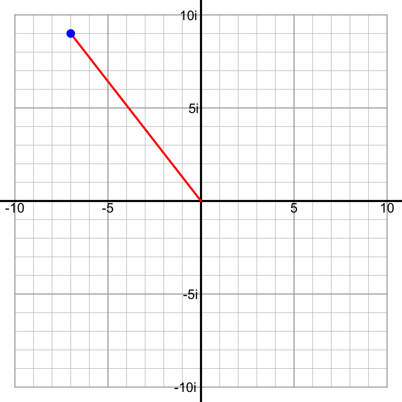

The [modulus](https://en.wikipedia.org/wiki/Absolute_value#Complex_numbers) of a complex number is analogous to finding distance on a 2D Cartesian plane from the origin to a point. If complex number $z=a+bi$ then its modulus, $|z|$, is calculated with a variation on the distance formula:
$$|z|=\sqrt{a^2+b^2}$$
Calculate $|z_1|$. *The tolerance is $\pm 0.01$.*

The horizontal (real) component is -7. The vertical (imaginary) component is 9. So,
$$z_1 =
-7+9i$$

Use the formula.
$$|z_1| =
\sqrt{(-7)^2+(9)^2}$$
$$|z_1| =
\sqrt{49+81}$$
$$|z_1| = \sqrt{130}
\approx 11.4017543$$

In [complex analysis](https://en.wikipedia.org/wiki/Complex_analysis), complex numbers are used as inputs and outputs of various functions.

Consider the function $f$ defined below.

$$f(x)~=~{6}x^{2}+{5}x+{4}$$

Evaluate $f(-2-8i)$.

You answer should be a complex number. Type the complex number **without spaces**, with the real term first and the imaginary term second. So your answer should look like `5+7i` or `-11+9i`.

$$f(-2-8i) ~=~
6(-2-8i)^2+5(-2-8i)+4$$

The most challenging part is squaring the complex input. Remember, raising to the power of 2 means multiplying by itself. When we multiply two complex numbers, we basically "FOIL".

$$(-2-8i)^2~\equiv~(-2-8i)(-2-8i)~\equiv~4+16i+16i+64i^2$$

Remember, $i^2=-1$.

$$(-2-8i)^2~\equiv~4+16i+16i-64$$

Combine like terms.

$$(-2-8i)^2~\equiv~-60+32i$$

So, now return to the full expression, replacing $(-2-8i)^2$ with $-60+32i$.

$$f(-2-8i) ~=~
6(-60+32i)+5(-2-8i)+4$$

Distribute.

$$f(-2-8i) ~=~
-360+192i-10-40i+4$$

Combine like terms.

$$f(-2-8i) ~=~ -366+152i$$

So, type your answer as `-366+152i`.

In [complex analysis](https://en.wikipedia.org/wiki/Complex_analysis), complex numbers are used as inputs and outputs of various functions.

Consider the function $f$ defined below.

$$f(x)~=~{-2}x^{2}-{6}x+{5}$$

Evaluate $f(-3+9i)$.

You answer should be a complex number. Type the complex number **without spaces**, with the real term first and the imaginary term second. So your answer should look like `5+7i` or `-11+9i`.

$$f(-3+9i) ~=~
-2(-3+9i)^2-6(-3+9i)+5$$

The most challenging part is squaring the complex input. Remember, raising to the power of 2 means multiplying by itself. When we multiply two complex numbers, we basically "FOIL".

$$(-3+9i)^2~\equiv~(-3+9i)(-3+9i)~\equiv~9-27i-27i+81i^2$$

Remember, $i^2=-1$.

$$(-3+9i)^2~\equiv~9-27i-27i-81$$

Combine like terms.

$$(-3+9i)^2~\equiv~-72-54i$$

So, now return to the full expression, replacing $(-3+9i)^2$ with $-72-54i$.

$$f(-3+9i) ~=~
-2(-72-54i)-6(-3+9i)+5$$

Distribute.

$$f(-3+9i) ~=~
144+108i+18-54i+5$$

Combine like terms.

$$f(-3+9i) ~=~ 167+54i$$

So, type your answer as `167+54i`.

In [complex analysis](https://en.wikipedia.org/wiki/Complex_analysis), complex numbers are used as inputs and outputs of various functions.

Consider the function $f$ defined below.

$$f(x)~=~{-9}x^{2}+{3}x-{5}$$

Evaluate $f(7+8i)$.

You answer should be a complex number. Type the complex number **without spaces**, with the real term first and the imaginary term second. So your answer should look like `5+7i` or `-11+9i`.

$$f(7+8i) ~=~
-9(7+8i)^2+3(7+8i)-5$$

The most challenging part is squaring the complex input. Remember, raising to the power of 2 means multiplying by itself. When we multiply two complex numbers, we basically "FOIL".

$$(7+8i)^2~\equiv~(7+8i)(7+8i)~\equiv~49+56i+56i+64i^2$$

Remember, $i^2=-1$.

$$(7+8i)^2~\equiv~49+56i+56i-64$$

Combine like terms.

$$(7+8i)^2~\equiv~-15+112i$$

So, now return to the full expression, replacing $(7+8i)^2$ with $-15+112i$.

$$f(7+8i) ~=~
-9(-15+112i)+3(7+8i)-5$$

Distribute.

$$f(7+8i) ~=~
135-1008i+21+24i-5$$

Combine like terms.

$$f(7+8i) ~=~ 151-984i$$

So, type your answer as `151-984i`.

In [complex analysis](https://en.wikipedia.org/wiki/Complex_analysis), complex numbers are used as inputs and outputs of various functions.

Consider the function $f$ defined below.

$$f(x)~=~{-8}x^{2}-{9}x-{7}$$

Evaluate $f(2-4i)$.

You answer should be a complex number. Type the complex number **without spaces**, with the real term first and the imaginary term second. So your answer should look like `5+7i` or `-11+9i`.

$$f(2-4i) ~=~
-8(2-4i)^2-9(2-4i)-7$$

The most challenging part is squaring the complex input. Remember, raising to the power of 2 means multiplying by itself. When we multiply two complex numbers, we basically "FOIL".

$$(2-4i)^2~\equiv~(2-4i)(2-4i)~\equiv~4-8i-8i+16i^2$$

Remember, $i^2=-1$.

$$(2-4i)^2~\equiv~4-8i-8i-16$$

Combine like terms.

$$(2-4i)^2~\equiv~-12-16i$$

So, now return to the full expression, replacing $(2-4i)^2$ with $-12-16i$.

$$f(2-4i) ~=~
-8(-12-16i)-9(2-4i)-7$$

Distribute.

$$f(2-4i) ~=~
96+128i-18+36i-7$$

Combine like terms.

$$f(2-4i) ~=~ 71+164i$$

So, type your answer as `71+164i`.

In [complex analysis](https://en.wikipedia.org/wiki/Complex_analysis), complex numbers are used as inputs and outputs of various functions.

Consider the function $f$ defined below.

$$f(x)~=~{5}x^{2}+{9}x+{3}$$

Evaluate $f(-2-4i)$.

You answer should be a complex number. Type the complex number **without spaces**, with the real term first and the imaginary term second. So your answer should look like `5+7i` or `-11+9i`.

$$f(-2-4i) ~=~
5(-2-4i)^2+9(-2-4i)+3$$

The most challenging part is squaring the complex input. Remember, raising to the power of 2 means multiplying by itself. When we multiply two complex numbers, we basically "FOIL".

$$(-2-4i)^2~\equiv~(-2-4i)(-2-4i)~\equiv~4+8i+8i+16i^2$$

Remember, $i^2=-1$.

$$(-2-4i)^2~\equiv~4+8i+8i-16$$

Combine like terms.

$$(-2-4i)^2~\equiv~-12+16i$$

So, now return to the full expression, replacing $(-2-4i)^2$ with $-12+16i$.

$$f(-2-4i) ~=~
5(-12+16i)+9(-2-4i)+3$$

Distribute.

$$f(-2-4i) ~=~
-60+80i-18-36i+3$$

Combine like terms.

$$f(-2-4i) ~=~ -75+44i$$

So, type your answer as `-75+44i`.

In [complex analysis](https://en.wikipedia.org/wiki/Complex_analysis), complex numbers are used as inputs and outputs of various functions.

Consider the function $f$ defined below.

$$f(x)~=~{6}x^{2}-{4}x+{5}$$

Evaluate $f(-8-9i)$.

You answer should be a complex number. Type the complex number **without spaces**, with the real term first and the imaginary term second. So your answer should look like `5+7i` or `-11+9i`.

$$f(-8-9i) ~=~
6(-8-9i)^2-4(-8-9i)+5$$

The most challenging part is squaring the complex input. Remember, raising to the power of 2 means multiplying by itself. When we multiply two complex numbers, we basically "FOIL".

$$(-8-9i)^2~\equiv~(-8-9i)(-8-9i)~\equiv~64+72i+72i+81i^2$$

Remember, $i^2=-1$.

$$(-8-9i)^2~\equiv~64+72i+72i-81$$

Combine like terms.

$$(-8-9i)^2~\equiv~-17+144i$$

So, now return to the full expression, replacing $(-8-9i)^2$ with $-17+144i$.

$$f(-8-9i) ~=~
6(-17+144i)-4(-8-9i)+5$$

Distribute.

$$f(-8-9i) ~=~
-102+864i+32+36i+5$$

Combine like terms.

$$f(-8-9i) ~=~ -65+900i$$

So, type your answer as `-65+900i`.

In [complex analysis](https://en.wikipedia.org/wiki/Complex_analysis), complex numbers are used as inputs and outputs of various functions.

Consider the function $f$ defined below.

$$f(x)~=~{7}x^{2}+{3}x-{6}$$

Evaluate $f(-9+8i)$.

You answer should be a complex number. Type the complex number **without spaces**, with the real term first and the imaginary term second. So your answer should look like `5+7i` or `-11+9i`.

$$f(-9+8i) ~=~
7(-9+8i)^2+3(-9+8i)-6$$

The most challenging part is squaring the complex input. Remember, raising to the power of 2 means multiplying by itself. When we multiply two complex numbers, we basically "FOIL".

$$(-9+8i)^2~\equiv~(-9+8i)(-9+8i)~\equiv~81-72i-72i+64i^2$$

Remember, $i^2=-1$.

$$(-9+8i)^2~\equiv~81-72i-72i-64$$

Combine like terms.

$$(-9+8i)^2~\equiv~17-144i$$

So, now return to the full expression, replacing $(-9+8i)^2$ with $17-144i$.

$$f(-9+8i) ~=~
7(17-144i)+3(-9+8i)-6$$

Distribute.

$$f(-9+8i) ~=~
119-1008i-27+24i-6$$

Combine like terms.

$$f(-9+8i) ~=~ 86-984i$$

So, type your answer as `86-984i`.

In [complex analysis](https://en.wikipedia.org/wiki/Complex_analysis), complex numbers are used as inputs and outputs of various functions.

Consider the function $f$ defined below.

$$f(x)~=~{-4}x^{2}-{6}x-{3}$$

Evaluate $f(2-9i)$.

You answer should be a complex number. Type the complex number **without spaces**, with the real term first and the imaginary term second. So your answer should look like `5+7i` or `-11+9i`.

$$f(2-9i) ~=~
-4(2-9i)^2-6(2-9i)-3$$

The most challenging part is squaring the complex input. Remember, raising to the power of 2 means multiplying by itself. When we multiply two complex numbers, we basically "FOIL".

$$(2-9i)^2~\equiv~(2-9i)(2-9i)~\equiv~4-18i-18i+81i^2$$

Remember, $i^2=-1$.

$$(2-9i)^2~\equiv~4-18i-18i-81$$

Combine like terms.

$$(2-9i)^2~\equiv~-77-36i$$

So, now return to the full expression, replacing $(2-9i)^2$ with $-77-36i$.

$$f(2-9i) ~=~
-4(-77-36i)-6(2-9i)-3$$

Distribute.

$$f(2-9i) ~=~
308+144i-12+54i-3$$

Combine like terms.

$$f(2-9i) ~=~ 293+198i$$

So, type your answer as `293+198i`.

In [complex analysis](https://en.wikipedia.org/wiki/Complex_analysis), complex numbers are used as inputs and outputs of various functions.

Consider the function $f$ defined below.

$$f(x)~=~{6}x^{2}-{5}x-{8}$$

Evaluate $f(3-4i)$.

You answer should be a complex number. Type the complex number **without spaces**, with the real term first and the imaginary term second. So your answer should look like `5+7i` or `-11+9i`.

$$f(3-4i) ~=~
6(3-4i)^2-5(3-4i)-8$$

The most challenging part is squaring the complex input. Remember, raising to the power of 2 means multiplying by itself. When we multiply two complex numbers, we basically "FOIL".

$$(3-4i)^2~\equiv~(3-4i)(3-4i)~\equiv~9-12i-12i+16i^2$$

Remember, $i^2=-1$.

$$(3-4i)^2~\equiv~9-12i-12i-16$$

Combine like terms.

$$(3-4i)^2~\equiv~-7-24i$$

So, now return to the full expression, replacing $(3-4i)^2$ with $-7-24i$.

$$f(3-4i) ~=~
6(-7-24i)-5(3-4i)-8$$

Distribute.

$$f(3-4i) ~=~
-42-144i-15+20i-8$$

Combine like terms.

$$f(3-4i) ~=~ -65-124i$$

So, type your answer as `-65-124i`.

In [complex analysis](https://en.wikipedia.org/wiki/Complex_analysis), complex numbers are used as inputs and outputs of various functions.

Consider the function $f$ defined below.

$$f(x)~=~{-8}x^{2}-{6}x-{2}$$

Evaluate $f(-3-9i)$.

You answer should be a complex number. Type the complex number **without spaces**, with the real term first and the imaginary term second. So your answer should look like `5+7i` or `-11+9i`.

$$f(-3-9i) ~=~
-8(-3-9i)^2-6(-3-9i)-2$$

The most challenging part is squaring the complex input. Remember, raising to the power of 2 means multiplying by itself. When we multiply two complex numbers, we basically "FOIL".

$$(-3-9i)^2~\equiv~(-3-9i)(-3-9i)~\equiv~9+27i+27i+81i^2$$

Remember, $i^2=-1$.

$$(-3-9i)^2~\equiv~9+27i+27i-81$$

Combine like terms.

$$(-3-9i)^2~\equiv~-72+54i$$

So, now return to the full expression, replacing $(-3-9i)^2$ with $-72+54i$.

$$f(-3-9i) ~=~
-8(-72+54i)-6(-3-9i)-2$$

Distribute.

$$f(-3-9i) ~=~
576-432i+18+54i-2$$

Combine like terms.

$$f(-3-9i) ~=~ 592-378i$$

So, type your answer as `592-378i`.

In [complex analysis](https://en.wikipedia.org/wiki/Complex_analysis), complex numbers are used as inputs and outputs of various functions.

Consider the function $f$ defined below.

$$f(x)~=~{-7}x^{2}-{6}x-{2}$$

Evaluate $\Big|f(-5+8i)\Big|$. In other words, find the [modulus](https://en.wikipedia.org/wiki/Absolute_value#Complex_numbers) of the output of $f$ when the input is $-5+8i$.

*The tolerance is $\pm 0.1$.*

$$f(-5+8i) ~=~
-7(-5+8i)^2-6(-5+8i)-2$$

The most challenging part is squaring the complex input. Remember, raising to the power of 2 means multiplying by itself. When we multiply two complex numbers, we basically "FOIL".

$$(-5+8i)^2~\equiv~(-5+8i)(-5+8i)~\equiv~25-40i-40i+64i^2$$

Remember, $i^2=-1$.

$$(-5+8i)^2~\equiv~25-40i-40i-64$$

Combine like terms.

$$(-5+8i)^2~\equiv~-39-80i$$

So, now return to the full expression, replacing $(-5+8i)^2$ with $-39-80i$.

$$f(-5+8i) ~=~
-7(-39-80i)-6(-5+8i)-2$$

Distribute.

$$f(-5+8i) ~=~
273+560i+30-48i-2$$

Combine like terms.

$$f(-5+8i) ~=~ 301+512i$$

Use the formula for the modulus.

$$\sqrt{(301)^2+(512)^2} ~=~
593.9233957$$

Thus, the correct answer is 593.9233957.

In [complex analysis](https://en.wikipedia.org/wiki/Complex_analysis), complex numbers are used as inputs and outputs of various functions.

Consider the function $f$ defined below.

$$f(x)~=~{4}x^{2}+{2}x-{8}$$

Evaluate $\Big|f(-6+9i)\Big|$. In other words, find the [modulus](https://en.wikipedia.org/wiki/Absolute_value#Complex_numbers) of the output of $f$ when the input is $-6+9i$.

*The tolerance is $\pm 0.1$.*

$$f(-6+9i) ~=~
4(-6+9i)^2+2(-6+9i)-8$$

The most challenging part is squaring the complex input. Remember, raising to the power of 2 means multiplying by itself. When we multiply two complex numbers, we basically "FOIL".

$$(-6+9i)^2~\equiv~(-6+9i)(-6+9i)~\equiv~36-54i-54i+81i^2$$

Remember, $i^2=-1$.

$$(-6+9i)^2~\equiv~36-54i-54i-81$$

Combine like terms.

$$(-6+9i)^2~\equiv~-45-108i$$

So, now return to the full expression, replacing $(-6+9i)^2$ with $-45-108i$.

$$f(-6+9i) ~=~
4(-45-108i)+2(-6+9i)-8$$

Distribute.

$$f(-6+9i) ~=~
-180-432i-12+18i-8$$

Combine like terms.

$$f(-6+9i) ~=~ -200-414i$$

Use the formula for the modulus.

$$\sqrt{(-200)^2+(-414)^2} ~=~
459.7782074$$

Thus, the correct answer is 459.7782074.

In [complex analysis](https://en.wikipedia.org/wiki/Complex_analysis), complex numbers are used as inputs and outputs of various functions.

Consider the function $f$ defined below.

$$f(x)~=~{7}x^{2}-{9}x-{4}$$

Evaluate $\Big|f(-8-6i)\Big|$. In other words, find the [modulus](https://en.wikipedia.org/wiki/Absolute_value#Complex_numbers) of the output of $f$ when the input is $-8-6i$.

*The tolerance is $\pm 0.1$.*

$$f(-8-6i) ~=~
7(-8-6i)^2-9(-8-6i)-4$$

The most challenging part is squaring the complex input. Remember, raising to the power of 2 means multiplying by itself. When we multiply two complex numbers, we basically "FOIL".

$$(-8-6i)^2~\equiv~(-8-6i)(-8-6i)~\equiv~64+48i+48i+36i^2$$

Remember, $i^2=-1$.

$$(-8-6i)^2~\equiv~64+48i+48i-36$$

Combine like terms.

$$(-8-6i)^2~\equiv~28+96i$$

So, now return to the full expression, replacing $(-8-6i)^2$ with $28+96i$.

$$f(-8-6i) ~=~
7(28+96i)-9(-8-6i)-4$$

Distribute.

$$f(-8-6i) ~=~
196+672i+72+54i-4$$

Combine like terms.

$$f(-8-6i) ~=~ 264+726i$$

Use the formula for the modulus.

$$\sqrt{(264)^2+(726)^2} ~=~
772.5101941$$

Thus, the correct answer is 772.5101941.

In [complex analysis](https://en.wikipedia.org/wiki/Complex_analysis), complex numbers are used as inputs and outputs of various functions.

Consider the function $f$ defined below.

$$f(x)~=~{4}x^{2}-{3}x+{9}$$

Evaluate $\Big|f(5-2i)\Big|$. In other words, find the [modulus](https://en.wikipedia.org/wiki/Absolute_value#Complex_numbers) of the output of $f$ when the input is $5-2i$.

*The tolerance is $\pm 0.1$.*

$$f(5-2i) ~=~
4(5-2i)^2-3(5-2i)+9$$

The most challenging part is squaring the complex input. Remember, raising to the power of 2 means multiplying by itself. When we multiply two complex numbers, we basically "FOIL".

$$(5-2i)^2~\equiv~(5-2i)(5-2i)~\equiv~25-10i-10i+4i^2$$

Remember, $i^2=-1$.

$$(5-2i)^2~\equiv~25-10i-10i-4$$

Combine like terms.

$$(5-2i)^2~\equiv~21-20i$$

So, now return to the full expression, replacing $(5-2i)^2$ with $21-20i$.

$$f(5-2i) ~=~
4(21-20i)-3(5-2i)+9$$

Distribute.

$$f(5-2i) ~=~ 84-80i-15+6i+9$$

Combine like terms.

$$f(5-2i) ~=~ 78-74i$$

Use the formula for the modulus.

$$\sqrt{(78)^2+(-74)^2} ~=~
107.5174404$$

Thus, the correct answer is 107.5174404.

In [complex analysis](https://en.wikipedia.org/wiki/Complex_analysis), complex numbers are used as inputs and outputs of various functions.

Consider the function $f$ defined below.

$$f(x)~=~{3}x^{2}+{2}x+{4}$$

Evaluate $\Big|f(-7+6i)\Big|$. In other words, find the [modulus](https://en.wikipedia.org/wiki/Absolute_value#Complex_numbers) of the output of $f$ when the input is $-7+6i$.

*The tolerance is $\pm 0.1$.*

$$f(-7+6i) ~=~
3(-7+6i)^2+2(-7+6i)+4$$

The most challenging part is squaring the complex input. Remember, raising to the power of 2 means multiplying by itself. When we multiply two complex numbers, we basically "FOIL".

$$(-7+6i)^2~\equiv~(-7+6i)(-7+6i)~\equiv~49-42i-42i+36i^2$$

Remember, $i^2=-1$.

$$(-7+6i)^2~\equiv~49-42i-42i-36$$

Combine like terms.

$$(-7+6i)^2~\equiv~13-84i$$

So, now return to the full expression, replacing $(-7+6i)^2$ with $13-84i$.

$$f(-7+6i) ~=~
3(13-84i)+2(-7+6i)+4$$

Distribute.

$$f(-7+6i) ~=~
39-252i-14+12i+4$$

Combine like terms.

$$f(-7+6i) ~=~ 29-240i$$

Use the formula for the modulus.

$$\sqrt{(29)^2+(-240)^2} ~=~
241.7457342$$

Thus, the correct answer is 241.7457342.

In [complex analysis](https://en.wikipedia.org/wiki/Complex_analysis), complex numbers are used as inputs and outputs of various functions.

Consider the function $f$ defined below.

$$f(x)~=~{-9}x^{2}-{7}x+{2}$$

Evaluate $\Big|f(3-8i)\Big|$. In other words, find the [modulus](https://en.wikipedia.org/wiki/Absolute_value#Complex_numbers) of the output of $f$ when the input is $3-8i$.

*The tolerance is $\pm 0.1$.*

$$f(3-8i) ~=~
-9(3-8i)^2-7(3-8i)+2$$

The most challenging part is squaring the complex input. Remember, raising to the power of 2 means multiplying by itself. When we multiply two complex numbers, we basically "FOIL".

$$(3-8i)^2~\equiv~(3-8i)(3-8i)~\equiv~9-24i-24i+64i^2$$

Remember, $i^2=-1$.

$$(3-8i)^2~\equiv~9-24i-24i-64$$

Combine like terms.

$$(3-8i)^2~\equiv~-55-48i$$

So, now return to the full expression, replacing $(3-8i)^2$ with $-55-48i$.

$$f(3-8i) ~=~
-9(-55-48i)-7(3-8i)+2$$

Distribute.

$$f(3-8i) ~=~
495+432i-21+56i+2$$

Combine like terms.

$$f(3-8i) ~=~ 476+488i$$

Use the formula for the modulus.

$$\sqrt{(476)^2+(488)^2} ~=~
681.703748$$

Thus, the correct answer is 681.703748.

In [complex analysis](https://en.wikipedia.org/wiki/Complex_analysis), complex numbers are used as inputs and outputs of various functions.

Consider the function $f$ defined below.

$$f(x)~=~{-7}x^{2}+{9}x-{8}$$

Evaluate $\Big|f(-2+5i)\Big|$. In other words, find the [modulus](https://en.wikipedia.org/wiki/Absolute_value#Complex_numbers) of the output of $f$ when the input is $-2+5i$.

*The tolerance is $\pm 0.1$.*

$$f(-2+5i) ~=~
-7(-2+5i)^2+9(-2+5i)-8$$

The most challenging part is squaring the complex input. Remember, raising to the power of 2 means multiplying by itself. When we multiply two complex numbers, we basically "FOIL".

$$(-2+5i)^2~\equiv~(-2+5i)(-2+5i)~\equiv~4-10i-10i+25i^2$$

Remember, $i^2=-1$.

$$(-2+5i)^2~\equiv~4-10i-10i-25$$

Combine like terms.

$$(-2+5i)^2~\equiv~-21-20i$$

So, now return to the full expression, replacing $(-2+5i)^2$ with $-21-20i$.

$$f(-2+5i) ~=~
-7(-21-20i)+9(-2+5i)-8$$

Distribute.

$$f(-2+5i) ~=~
147+140i-18+45i-8$$

Combine like terms.

$$f(-2+5i) ~=~ 121+185i$$

Use the formula for the modulus.

$$\sqrt{(121)^2+(185)^2} ~=~
221.0565538$$

Thus, the correct answer is 221.0565538.

In [complex analysis](https://en.wikipedia.org/wiki/Complex_analysis), complex numbers are used as inputs and outputs of various functions.

Consider the function $f$ defined below.

$$f(x)~=~{5}x^{2}-{9}x-{3}$$

Evaluate $\Big|f(-8-4i)\Big|$. In other words, find the [modulus](https://en.wikipedia.org/wiki/Absolute_value#Complex_numbers) of the output of $f$ when the input is $-8-4i$.

*The tolerance is $\pm 0.1$.*

$$f(-8-4i) ~=~
5(-8-4i)^2-9(-8-4i)-3$$

The most challenging part is squaring the complex input. Remember, raising to the power of 2 means multiplying by itself. When we multiply two complex numbers, we basically "FOIL".

$$(-8-4i)^2~\equiv~(-8-4i)(-8-4i)~\equiv~64+32i+32i+16i^2$$

Remember, $i^2=-1$.

$$(-8-4i)^2~\equiv~64+32i+32i-16$$

Combine like terms.

$$(-8-4i)^2~\equiv~48+64i$$

So, now return to the full expression, replacing $(-8-4i)^2$ with $48+64i$.

$$f(-8-4i) ~=~
5(48+64i)-9(-8-4i)-3$$

Distribute.

$$f(-8-4i) ~=~
240+320i+72+36i-3$$

Combine like terms.

$$f(-8-4i) ~=~ 309+356i$$

Use the formula for the modulus.

$$\sqrt{(309)^2+(356)^2} ~=~
471.3989818$$

Thus, the correct answer is 471.3989818.

In [complex analysis](https://en.wikipedia.org/wiki/Complex_analysis), complex numbers are used as inputs and outputs of various functions.

Consider the function $f$ defined below.

$$f(x)~=~{5}x^{2}+{8}x+{2}$$

Evaluate $\Big|f(4-9i)\Big|$. In other words, find the [modulus](https://en.wikipedia.org/wiki/Absolute_value#Complex_numbers) of the output of $f$ when the input is $4-9i$.

*The tolerance is $\pm 0.1$.*

$$f(4-9i) ~=~
5(4-9i)^2+8(4-9i)+2$$

The most challenging part is squaring the complex input. Remember, raising to the power of 2 means multiplying by itself. When we multiply two complex numbers, we basically "FOIL".

$$(4-9i)^2~\equiv~(4-9i)(4-9i)~\equiv~16-36i-36i+81i^2$$

Remember, $i^2=-1$.

$$(4-9i)^2~\equiv~16-36i-36i-81$$

Combine like terms.

$$(4-9i)^2~\equiv~-65-72i$$

So, now return to the full expression, replacing $(4-9i)^2$ with $-65-72i$.

$$f(4-9i) ~=~
5(-65-72i)+8(4-9i)+2$$

Distribute.

$$f(4-9i) ~=~
-325-360i+32-72i+2$$

Combine like terms.

$$f(4-9i) ~=~ -291-432i$$

Use the formula for the modulus.

$$\sqrt{(-291)^2+(-432)^2} ~=~
520.8694654$$

Thus, the correct answer is 520.8694654.

In [complex analysis](https://en.wikipedia.org/wiki/Complex_analysis), complex numbers are used as inputs and outputs of various functions.

Consider the function $f$ defined below.

$$f(x)~=~{-4}x^{2}-{6}x-{7}$$

Evaluate $\Big|f(-2-8i)\Big|$. In other words, find the [modulus](https://en.wikipedia.org/wiki/Absolute_value#Complex_numbers) of the output of $f$ when the input is $-2-8i$.

*The tolerance is $\pm 0.1$.*

$$f(-2-8i) ~=~
-4(-2-8i)^2-6(-2-8i)-7$$

The most challenging part is squaring the complex input. Remember, raising to the power of 2 means multiplying by itself. When we multiply two complex numbers, we basically "FOIL".

$$(-2-8i)^2~\equiv~(-2-8i)(-2-8i)~\equiv~4+16i+16i+64i^2$$

Remember, $i^2=-1$.

$$(-2-8i)^2~\equiv~4+16i+16i-64$$

Combine like terms.

$$(-2-8i)^2~\equiv~-60+32i$$

So, now return to the full expression, replacing $(-2-8i)^2$ with $-60+32i$.

$$f(-2-8i) ~=~
-4(-60+32i)-6(-2-8i)-7$$

Distribute.

$$f(-2-8i) ~=~
240-128i+12+48i-7$$

Combine like terms.

$$f(-2-8i) ~=~ 245-80i$$

Use the formula for the modulus.

$$\sqrt{(245)^2+(-80)^2} ~=~
257.7304794$$

Thus, the correct answer is 257.7304794.

Does the complex number $z=3-2i$ solve the equation below?

$$z^2-5z+10=0$$

YesNo

Plug in $z=3-2i$. Since we are checking if this equation is true, we should probably put a question mark above the equal sign. I didn't, but keep in mind these equations might be wrong.

$$(3-2i)^2-5(3-2i)+10=0$$

Expand the terms. Use FOIL for the squared term.

$$9-6i-6i+4i^2-15+10i+10=0$$

Remember $i^2=-1$.
$$9-6i-6i-4-15+10i+10=0$$
Combine like terms.
$$0-2i=0$$
Nope! The complex number does not satisfy the equation!

Does the complex number $z=9-6i$ solve the equation below?

$$z^2-18z+117=0$$

YesNo

Plug in $z=9-6i$. Since we are checking if this equation is true, we should probably put a question mark above the equal sign. I didn't, but keep in mind these equations might be wrong.

$$(9-6i)^2-18(9-6i)+117=0$$

Expand the terms. Use FOIL for the squared term.

$$81-54i-54i+36i^2-162+108i+117=0$$

Remember $i^2=-1$.
$$81-54i-54i-36-162+108i+117=0$$
Combine like terms.
$$0+0i=0$$
Yay! The complex number satisfies the equation!

Does the complex number $z=8-2i$ solve the equation below?

$$z^2-16z+63=0$$

YesNo

Plug in $z=8-2i$. Since we are checking if this equation is true, we should probably put a question mark above the equal sign. I didn't, but keep in mind these equations might be wrong.

$$(8-2i)^2-16(8-2i)+63=0$$

Expand the terms. Use FOIL for the squared term.

$$64-16i-16i+4i^2-128+32i+63=0$$

Remember $i^2=-1$.
$$64-16i-16i-4-128+32i+63=0$$
Combine like terms.
$$-5+0i=0$$
Nope! The complex number does not satisfy the equation!

Does the complex number $z=-9-7i$ solve the equation below?

$$z^2+18z+130=0$$

YesNo

Plug in $z=-9-7i$. Since we are checking if this equation is true, we should probably put a question mark above the equal sign. I didn't, but keep in mind these equations might be wrong.

$$(-9-7i)^2+18(-9-7i)+130=0$$

Expand the terms. Use FOIL for the squared term.

$$81+63i+63i+49i^2-162-126i+130=0$$

Remember $i^2=-1$.
$$81+63i+63i-49-162-126i+130=0$$
Combine like terms.
$$0+0i=0$$
Yay! The complex number satisfies the equation!

Does the complex number $z=-7+5i$ solve the equation below?

$$z^2+14z+74=0$$

YesNo

Plug in $z=-7+5i$. Since we are checking if this equation is true, we should probably put a question mark above the equal sign. I didn't, but keep in mind these equations might be wrong.

$$(-7+5i)^2+14(-7+5i)+74=0$$

Expand the terms. Use FOIL for the squared term.

$$49-35i-35i+25i^2-98+70i+74=0$$

Remember $i^2=-1$.
$$49-35i-35i-25-98+70i+74=0$$
Combine like terms.
$$0+0i=0$$
Yay! The complex number satisfies the equation!

Does the complex number $z=-7-8i$ solve the equation below?

$$z^2+16z+110=0$$

YesNo

Plug in $z=-7-8i$. Since we are checking if this equation is true, we should probably put a question mark above the equal sign. I didn't, but keep in mind these equations might be wrong.

$$(-7-8i)^2+16(-7-8i)+110=0$$

Expand the terms. Use FOIL for the squared term.

$$49+56i+56i+64i^2-112-128i+110=0$$

Remember $i^2=-1$.
$$49+56i+56i-64-112-128i+110=0$$
Combine like terms.
$$-17-16i=0$$
Nope! The complex number does not satisfy the equation!

Does the complex number $z=4-2i$ solve the equation below?

$$z^2-8z+20=0$$

YesNo

Plug in $z=4-2i$. Since we are checking if this equation is true, we should probably put a question mark above the equal sign. I didn't, but keep in mind these equations might be wrong.

$$(4-2i)^2-8(4-2i)+20=0$$

Expand the terms. Use FOIL for the squared term.

$$16-8i-8i+4i^2-32+16i+20=0$$

Remember $i^2=-1$.
$$16-8i-8i-4-32+16i+20=0$$
Combine like terms.
$$0+0i=0$$
Yay! The complex number satisfies the equation!

Does the complex number $z=-4+6i$ solve the equation below?

$$z^2+8z+49=0$$

YesNo

Plug in $z=-4+6i$. Since we are checking if this equation is true, we should probably put a question mark above the equal sign. I didn't, but keep in mind these equations might be wrong.

$$(-4+6i)^2+8(-4+6i)+49=0$$

Expand the terms. Use FOIL for the squared term.

$$16-24i-24i+36i^2-32+48i+49=0$$

Remember $i^2=-1$.
$$16-24i-24i-36-32+48i+49=0$$
Combine like terms.
$$-3+0i=0$$
Nope! The complex number does not satisfy the equation!

Does the complex number $z=3-9i$ solve the equation below?

$$z^2-6z+90=0$$

YesNo

Plug in $z=3-9i$. Since we are checking if this equation is true, we should probably put a question mark above the equal sign. I didn't, but keep in mind these equations might be wrong.

$$(3-9i)^2-6(3-9i)+90=0$$

Expand the terms. Use FOIL for the squared term.

$$9-27i-27i+81i^2-18+54i+90=0$$

Remember $i^2=-1$.
$$9-27i-27i-81-18+54i+90=0$$
Combine like terms.
$$0+0i=0$$
Yay! The complex number satisfies the equation!

Does the complex number $z=7+2i$ solve the equation below?

$$z^2-12z+49=0$$

YesNo

Plug in $z=7+2i$. Since we are checking if this equation is true, we should probably put a question mark above the equal sign. I didn't, but keep in mind these equations might be wrong.

$$(7+2i)^2-12(7+2i)+49=0$$

Expand the terms. Use FOIL for the squared term.

$$49+14i+14i+4i^2-84-24i+49=0$$

Remember $i^2=-1$.
$$49+14i+14i-4-84-24i+49=0$$
Combine like terms.
$$10+4i=0$$
Nope! The complex number does not satisfy the equation!